# 01 텐서플로우 (Tensorflow)

### 배치 정규화

- 모델에 주입되는 샘플들을 균일하게 만드는 방법
- 학습 후 새로운 데이터에 잘 **일반화** 할 수 있도록 도와줌
- 데이터 전처리 단계에서 진행해도 되지만 정규화가 되어서 layer에 들어갔다는 보장이 없음
- 주로 **Dense** 또는 **Conv2D** Layer 후, **활성화 함수**이전에 놓임

```python
from tensorflow.keras.layers import BatchNormalization, Dense, Activation
```

```
Model: "sequential_5"
_________________________________________________________________
 Layer (type)                Output Shape              Param #
=================================================================
 dense_3 (Dense)             (None, 32)                25120

 batch_normalization_1 (Batc  (None, 32)               128
 hNormalization)

 activation_2 (Activation)   (None, 32)                0

=================================================================
Total params: 25,248
Trainable params: 25,184
Non-trainable params: 64
_________________________________________________________________
```

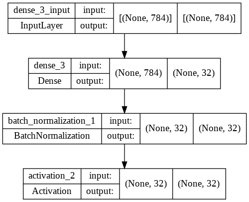

```python
model = Sequential()

model.add(Dense(32, input_shape = (28 * 28, ), kernel_initializer = 'he_normal'))
model.add(BatchNormalization())
model.add(Activation('relu'))

model.summary()
plot_model(model, show_shapes = True)
```

### 규제화

- 복잡한 네트워크 일수록 네트워크의 복잡도에 제한을 두어  
  가중치가 작은 값을 가지도록 함
- 가중치의 분포가 더 균일하게 됨
- **네트워크 손실함수에 큰 가중치에 연관된 비용을 추가**
  - **L1 규제 : 가중치의 절댓값에 비례하는 비용이 추가**
  - **L2 규제 : 가중치의 제곱에 비례하는 비용이 추가(흔히 가중치 감쇠라고도 불림), 과적합 방지(에포크가 반복되어도 검증손실의 증가를 방지)**
  - **위 2규제가 합쳐진 경우도 존재**

데이터는 **모델의 크기** 파트에서 사용된 imdb dataset

```python
from tensorflow.keras.regularizers import l1, l2, l1_l2
```

#### 모델 구성

```
Model: "sequential_8"
_________________________________________________________________
 Layer (type)                Output Shape              Param #
=================================================================
 dense_10 (Dense)            (None, 16)                160016

 dense_11 (Dense)            (None, 16)                272

 dense_12 (Dense)            (None, 1)                 17

=================================================================
Total params: 160,305
Trainable params: 160,305
Non-trainable params: 0
_________________________________________________________________
```

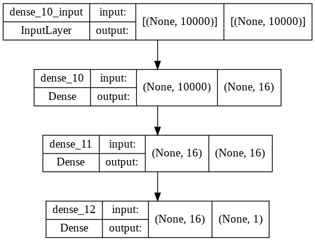

```python
l2_model = Sequential([Dense(16, kernel_regularizer = l2(0.001), activation = 'relu', input_shape = (10000,)),
                       Dense(16, kernel_regularizer = l2(0.001), activation = 'relu'),
                       Dense(1, activation = 'sigmoid')])

l2_model.compile(loss = 'binary_crossentropy',
                optimizer = 'rmsprop',
                metrics = ['acc'])

l2_model.summary()
plot_model(l2_model, show_shapes = True)
```

#### 모델 학습

```python
l2_model_hist = l2_model.fit(x_train, y_train, epochs = 20,
                             batch_size = 512, validation_data = (x_test, y_test), verbose = False)
```

#### 시각화

- Model 1은 **모델의 크기 축소**파트에서의 모델

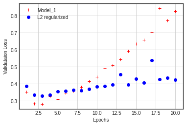

```python
l2_model_val_loss = l2_model_hist.history['val_loss']

epochs = range(1, 21)

plt.plot(epochs, model_1_val_loss, 'r+', label = 'Model_1')
plt.plot(epochs, l2_model_val_loss, 'bo', label = 'L2 regularized')
plt.xlabel('Epochs')
plt.ylabel('Validataion Loss')
plt.legend()
plt.grid()
plt.show()
```

#### L1과 비교

```
Model: "sequential_9"
_________________________________________________________________
 Layer (type)                Output Shape              Param #
=================================================================
 dense_13 (Dense)            (None, 16)                160016

 dense_14 (Dense)            (None, 16)                272

 dense_15 (Dense)            (None, 1)                 17

=================================================================
Total params: 160,305
Trainable params: 160,305
Non-trainable params: 0
_________________________________________________________________
```

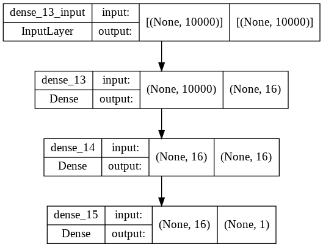

```python
l1_model = Sequential([Dense(16, kernel_regularizer = l1(0.0001), activation = 'relu', input_shape = (10000,)),
                       Dense(16, kernel_regularizer = l1(0.0001), activation = 'relu'),
                       Dense(1, activation = 'sigmoid')])

l1_model.compile(loss = 'binary_crossentropy',
                optimizer = 'rmsprop',
                metrics = ['acc'])

l1_model.summary()
plot_model(l1_model, show_shapes = True)
```

```python
l1_model_hist = l1_model.fit(x_train, y_train, epochs = 20,
                             batch_size = 512, validation_data = (x_test, y_test), verbose = False)
```

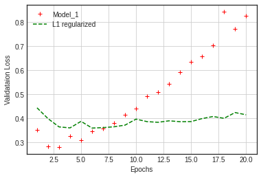

```python
l1_model_val_loss = l1_model_hist.history['val_loss']

epochs = range(1, 21)

plt.plot(epochs, model_1_val_loss, 'r+', label = 'Model_1')
plt.plot(epochs, l1_model_val_loss, 'g--', label = 'L1 regularized')
plt.xlabel('Epochs')
plt.ylabel('Validataion Loss')
plt.legend()
plt.grid()
plt.show()
```

3가지 모델 비교

- Original
- L1
- L2

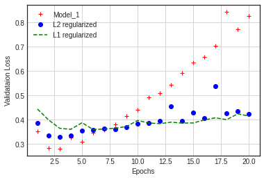

```python
plt.plot(epochs, model_1_val_loss, 'r+', label = 'Model_1')
plt.plot(epochs, l2_model_val_loss, 'bo', label = 'L2 regularized')
plt.plot(epochs, l1_model_val_loss, 'g--', label = 'L1 regularized')
plt.xlabel('Epochs')
plt.ylabel('Validataion Loss')
plt.legend()
plt.grid()
plt.show()
```

#### L1_L2와 비교

```
Model: "sequential_17"
_________________________________________________________________
 Layer (type)                Output Shape              Param #
=================================================================
 dense_37 (Dense)            (None, 16)                160016

 dense_38 (Dense)            (None, 16)                272

 dense_39 (Dense)            (None, 1)                 17

=================================================================
Total params: 160,305
Trainable params: 160,305
Non-trainable params: 0
_________________________________________________________________
```

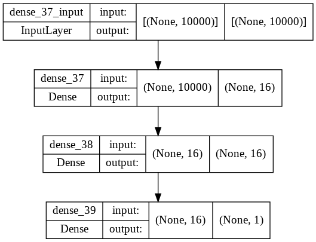

```python
l1_12_model = Sequential([Dense(16, kernel_regularizer = l1_l2(l1 = 0.0001, l2 = 0.0001),
                                activation = 'relu', input_shape = (10000,)),
                          Dense(16, kernel_regularizer = l1_l2(l1 = 0.0001, l2 = 0.0001),
                               activation = 'relu'),
                          Dense(1, activation = 'sigmoid')])

l1_12_model.compile(loss = 'binary_crossentropy', optimizer = 'rmsprop', metrics = ['acc'])
l1_12_model.summary()
plot_model(l1_12_model, show_shapes = True)
```

```python
l1_12_model_hist = l1_12_model.fit(x_train, y_train, epochs = 20,
                                  batch_size = 512, validation_data = (x_test, y_test), verbose = False)
```

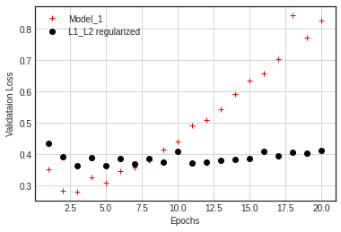

```python
l1_l2_model_val_loss = l1_12_model_hist.history['val_loss']

epochs = range(1, 21)

plt.plot(epochs, model_1_val_loss, 'r+', label = 'Model_1')
plt.plot(epochs, l1_l2_model_val_loss, 'ko', label = 'L1_L2 regularized')
plt.xlabel('Epochs')
plt.ylabel('Validataion Loss')
plt.legend()
plt.grid()
plt.show()
```

4가지 모델 비교

- Original
- L1
- L2
- L1_L2

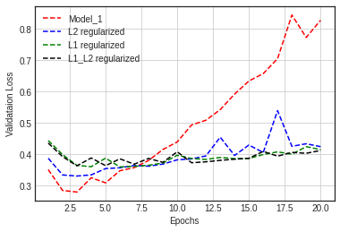

```python
plt.plot(epochs, model_1_val_loss, 'r--', label = 'Model_1')
plt.plot(epochs, l2_model_val_loss, 'b--', label = 'L2 regularized')
plt.plot(epochs, l1_model_val_loss, 'g--', label = 'L1 regularized')
plt.plot(epochs, l1_l2_model_val_loss, 'k--', label = 'L1_L2 regularized')
plt.xlabel('Epochs')
plt.ylabel('Validataion Loss')
plt.legend()
plt.grid()
plt.show()
```

### 드롭아웃(Dropout)

- 신경망을 위해 사용되는 규제 기법 중 가장 효과적이고 널리 사용되는 방법
- **신경망의 레이어에 드롭아웃을 적용하면 훈련하는 동안 무작위로 층의 일부 특성(노드)를 제외**
  - 예를 들어, [1.0, 3.2, 0.6, 0.8, 1.1] 라는 벡터에 대해 드롭아웃을 적용하면 **무작위로 0으로 바뀜**  
    => [0, 3.2, 0.6, 0.8, 0]
  - **보통 0.2 ~ 0.5 사이의 비율로 지정됨**
- 테스트 단계에서는 그 어떤 노드도 드롭아웃 되지 않는다.
  - 대신 해당 레이어의 출력 노드를 드롭아웃 비율에 맞게 줄여줌

훈련과정에서 층에 있는 일부 뉴런을 랜덤하게 종료(해당 뉴런의 출력을 0으로) => 과대적합 방지

#### **드롭아웃 할 비율 = r, 드롭아웃 하지 않는 뉴런의 출력은 1/(1-r)만큼 증가 => 출력의 총합이 같게**

- 얼마나 많은 뉴런을 드롭할지는 하이퍼파라미터

```python
from tensorflow.keras.layers import Dropout
```

#### 모델 구성

```
Model: "sequential_2"
_________________________________________________________________
 Layer (type)                Output Shape              Param #
=================================================================
 dense (Dense)               (None, 16)                160016

 dropout (Dropout)           (None, 16)                0

 dense_1 (Dense)             (None, 16)                272

 dropout_1 (Dropout)         (None, 16)                0

 dense_2 (Dense)             (None, 1)                 17

=================================================================
Total params: 160,305
Trainable params: 160,305
Non-trainable params: 0
_________________________________________________________________
```

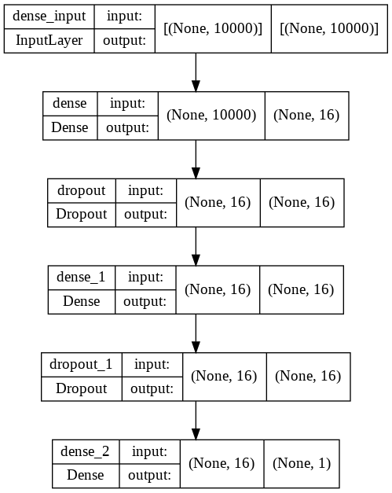

```python
dropout_model = Sequential([Dense(16, activation = 'relu', input_shape = (10000,)),
                            Dropout(0.5),
                            Dense(16, activation = 'relu'),
                            Dropout(0.5),
                            Dense(1, activation = 'sigmoid')])

dropout_model.compile(loss = 'binary_crossentropy', optimizer = 'rmsprop', metrics = ['acc'])
dropout_model.summary()
plot_model(dropout_model, show_shapes = True)
```

#### 모델 학습

```python
dropout_modell_hist = dropout_model.fit(x_train, y_train, epochs = 20,
                                       batch_size = 512, validation_data = (x_test, y_test), verbose = False)
```

#### 시각화

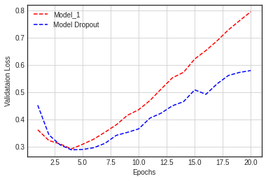

```python
dropout_model_val_loss = dropout_modell_hist.history['val_loss']

epochs = range(1, 21)
plt.plot(epochs, model_1_val_loss, 'r--', label = 'Model_1')
plt.plot(epochs, dropout_model_val_loss, 'b--', label = 'Model Dropout')
plt.xlabel('Epochs')
plt.ylabel('Validataion Loss')
plt.legend()
plt.grid()
plt.show()
```

# 05 Data API

- `tf.data`: https://www.tensorflow.org/api_docs/python/tf/data
- `tf.data.datasets`

## tf.data.datasets

```python
import tensorflow as tf
import tensorflow_datasets as tfds
```

```python
builders = tfds.list_builders()
# print(builders)
```

```python
data, info = tfds.load("mnist", with_info = True)
train_data, test_data = data['train'], data['test']
```

```python
info
```

```
tfds.core.DatasetInfo(
    name='mnist',
    version=3.0.1,
    description='The MNIST database of handwritten digits.',
    homepage='http://yann.lecun.com/exdb/mnist/',
    features=FeaturesDict({
        'image': Image(shape=(28, 28, 1), dtype=tf.uint8),
        'label': ClassLabel(shape=(), dtype=tf.int64, num_classes=10),
    }),
    total_num_examples=70000,
    splits={
        'test': 10000,
        'train': 60000,
    },
    supervised_keys=('image', 'label'),
    citation="""@article{lecun2010mnist,
      title={MNIST handwritten digit database},
      author={LeCun, Yann and Cortes, Corinna and Burges, CJ},
      journal={ATT Labs [Online]. Available: http://yann.lecun.com/exdb/mnist},
      volume={2},
      year={2010}
    }""",
    redistribution_info=,
)
```

## tf.data

- 생성
  - `from_tensor_slices()`: 개별 또는 다중 넘파이를 받고, 배치를 지원
  - `from_tensors()`: 배치를 지원하지 않음
  - `from_generator()`: 생성자 함수에서 입력을 취함
- 변환
  - `batch()`: 순차적으로 지정한 배치사이즈로 데이터셋을 분할
  - `repeat()`: 데이터를 복제
  - `shuffle()`: 데이터를 무작위로 섞음
  - `map()`: 데이터에 함수를 적용
  - `filter()`: 데이터를 거르고자 할 때 사용
- 반복
  - `next_batch = iterator.get_next()` 사용

### from_tensor_slices

```python
import numpy as np
```

```python
num_items = 20
num_list = np.arange(num_items)
```

```python
num_list_dataset = tf.data.Dataset.from_tensor_slices(num_list)
```

```python
num_list_dataset
```

```
<TensorSliceDataset element_spec=TensorSpec(shape=(), dtype=tf.int64, name=None)>
```

```python
for item in num_list_dataset:
  print(item)
```

```
tf.Tensor(0, shape=(), dtype=int64)
tf.Tensor(1, shape=(), dtype=int64)
tf.Tensor(2, shape=(), dtype=int64)
tf.Tensor(3, shape=(), dtype=int64)
tf.Tensor(4, shape=(), dtype=int64)
tf.Tensor(5, shape=(), dtype=int64)
tf.Tensor(6, shape=(), dtype=int64)
tf.Tensor(7, shape=(), dtype=int64)
tf.Tensor(8, shape=(), dtype=int64)
tf.Tensor(9, shape=(), dtype=int64)
tf.Tensor(10, shape=(), dtype=int64)
tf.Tensor(11, shape=(), dtype=int64)
tf.Tensor(12, shape=(), dtype=int64)
tf.Tensor(13, shape=(), dtype=int64)
tf.Tensor(14, shape=(), dtype=int64)
tf.Tensor(15, shape=(), dtype=int64)
tf.Tensor(16, shape=(), dtype=int64)
tf.Tensor(17, shape=(), dtype=int64)
tf.Tensor(18, shape=(), dtype=int64)
tf.Tensor(19, shape=(), dtype=int64)
```

### from_generator()

- 해당 클래스 메서드를 사용하면 생성자에서 데이터셋 생성 가능
- output_types, output_shapes 인수로 출력 자료형과 크기를 지정해주어야 함

### batch, repeat

- `batch()`: 배치 사이즈 크기
- `repeat()`: 반복 횟수

```python
dataset = num_list_dataset.repeat(3).batch(7)
# 배치 사이즈 7로 나누는 것을, 3번 반복
```

```python
for item in dataset:
  print(item)
```

```
tf.Tensor([0 1 2 3 4 5 6], shape=(7,), dtype=int64)
tf.Tensor([ 7  8  9 10 11 12 13], shape=(7,), dtype=int64)
tf.Tensor([14 15 16 17 18 19  0], shape=(7,), dtype=int64)
tf.Tensor([1 2 3 4 5 6 7], shape=(7,), dtype=int64)
tf.Tensor([ 8  9 10 11 12 13 14], shape=(7,), dtype=int64)
tf.Tensor([15 16 17 18 19  0  1], shape=(7,), dtype=int64)
tf.Tensor([2 3 4 5 6 7 8], shape=(7,), dtype=int64)
tf.Tensor([ 9 10 11 12 13 14 15], shape=(7,), dtype=int64)
tf.Tensor([16 17 18 19], shape=(4,), dtype=int64)
```

```python
dataset = num_list_dataset.repeat(3).batch(7, drop_remainder = True)
# 배치 사이즈 7로 나누는 것을, 나머지가 남지 않게 3번 반복
```

```python
for item in dataset:
  print(item)
```

```
tf.Tensor([0 1 2 3 4 5 6], shape=(7,), dtype=int64)
tf.Tensor([ 7  8  9 10 11 12 13], shape=(7,), dtype=int64)
tf.Tensor([14 15 16 17 18 19  0], shape=(7,), dtype=int64)
tf.Tensor([1 2 3 4 5 6 7], shape=(7,), dtype=int64)
tf.Tensor([ 8  9 10 11 12 13 14], shape=(7,), dtype=int64)
tf.Tensor([15 16 17 18 19  0  1], shape=(7,), dtype=int64)
tf.Tensor([2 3 4 5 6 7 8], shape=(7,), dtype=int64)
tf.Tensor([ 9 10 11 12 13 14 15], shape=(7,), dtype=int64)
```

### map, filter

- 전처리 단계에서 시행하여 원하지 않는 데이터를 거를 수 있음
- `tf.Tensor` 자료형을 다룸

### shuffle, take

```python
dataset, info = tfds.load('imdb_reviews', with_info = True, as_supervised = True)
```

```python
train_dataset = dataset['train']
train_dataset = train_dataset.batch(5).shuffle(5).take(2)
# 배치사이즈 5로 나누어서, 섞어서 2개만 호출

for data in train_dataset:
  print(data)
```

```
(<tf.Tensor: shape=(5,), dtype=string, numpy=
array([b'It was disgusting and painful. What a waste of a cast! I swear, the audience (1/2 full) laughed TWICE in 90 minutes. This is not a lie. Do not even rent it.<br /><br />Zeta Jones was just too mean to be believable.<br /><br />Cusack was OK. Just OK. I felt sorry for him (the actor) in case …
       b'This is a straight-to-video movie, so it should go without saying that it\'s not going to rival the first Lion King, but that said, this was downright good.<br /><br />My kids loved this, but that\'s a given, they love anything that\'s a cartoon. The big shock was that *I* liked it too, it …
       b'Finally, Timon and Pumbaa in their own film...<br /><br />\'The Lion King 1 1/2: Hakuna Matata\' is an irreverent new take on a classic tale. Which classic tale, you ask? Why, \'The Lion King\' of course!<br /><br />Yep, if there\'s one thing that Disney is never short of, it\'s narcissism.…
       b'Indian Directors have it tough, They have to compete with movies like "Laggan" where 11 henpecked,Castrated males defend their village and half of them are certifiable idiots. "Devdas", a hapless, fedar- festooned foreign return drinking to oblivion, with characters running in endless corri…
       b"Nathan Detroit runs illegal craps games for high rollers in NYC, but the heat is on and he can't find a secure location. He bets chronic gambler Sky Masterson that Sky can't make a prim missionary, Sarah Brown, go out to dinner with him. Sky takes up the challenge, but both men have some su…
      dtype=object)>, <tf.Tensor: shape=(5,), dtype=int64, numpy=array([0, 1, 1, 1, 0])>)
(<tf.Tensor: shape=(5,), dtype=string, numpy=
array([b"This was an absolutely terrible movie. Don't be lured in by Christopher Walken or Michael Ironside. Both are great actors, but this must simply be their worst role in history. Even their great acting could not redeem this movie's ridiculous storyline. This movie is an early nineties US prop…
       b'I have been known to fall asleep during films, but this is usually due to a combination of things including, really tired, being warm and comfortable on the sette and having just eaten a lot. However on this occasion I fell asleep because the film was rubbish. The plot development was const…
       b'Mann photographs the Alberta Rocky Mountains in a superb fashion, and Jimmy Stewart and Walter Brennan give enjoyable performances as they always seem to do. <br /><br />But come on Hollywood - a Mountie telling the people of Dawson City, Yukon to elect themselves a marshal (yes a marshal!)…
       b'This is the kind of film for a snowy Sunday afternoon when the rest of the world can go ahead with its own business as you descend into a big arm-chair and mellow for a couple of hours. Wonderful performances from Cher and Nicolas Cage (as always) gently row the plot along. There are no rap…
       b'As others have mentioned, all the women that go nude in this film are mostly absolutely gorgeous. The plot very ably shows the hypocrisy of the female libido. When men are around they want to be pursued, but when no "men" are around, they become the pursuers of a 14 year old boy. And the bo…
      dtype=object)>, <tf.Tensor: shape=(5,), dtype=int64, numpy=array([0, 0, 0, 1, 1])>)
```